# Credit Card Fraud

Jazib Jamal / Frenklin Kokoneshi

6/29/2017

## R Markdown File of the Project

## 1- Problem: “Classification type”

The problem on hand is to detect fraudulent credit card transactions automatically. Our goal is to create a model that can detect fraud transactions with maximum accuracy, while also having minimum errors with non-fraudulent transactions. It is a classification problem and we will use different classification models to predict fraudulent transactions vs non-fraudulent, with the highest possible accuracy. As customers, we understand how frustrating it can be when a purchase is made and the bank classifies it as fraud and cancels the card. Our goal is to solve those issues and accurately predict non-fraud as well as fraud.

## 2- Business Rationale

We want to train the system to be able to identify fraudulent transactions from clean ones. This should be done without the aid of human operators. There are many fraud transactions that are missed on a daily basis costing companies, banks, and individuals millions on a daily basis. There are also transactions that are deemed fraud and are non-fraud causing frustrations when customers are trying to make a purchase. A good model would flag fraud and minimize non-fraud transactions on a daily basis. This would save millions to companies, banks and individual users.

## 3- Description of Data

The data set we are using is sourced from Kaggle. It contains only numerical input variables which are the result of a PCA transformation (due to confidentiality). Features such as “V1”, “V2”, … “V28” are the principal components obtained with PCA. The only features which have not been transformed with PCA are ‘Time’ and ‘Amount’. Feature ‘Time’ contains the seconds elapsed between each transaction. The feature ‘Amount’ is the transaction Amount. Feature ‘Class’ is the binary response variable and it takes value 1 in case of fraud and 0 otherwise.

Link for data = https://www.kaggle.com/dalpozz/creditcardfraud

## Question 4 and 5 are answered throughout below.

Before we start working on data, we will load all the packages we need, followed by the loading the data.

```r
##Load Libraries and Data

library(gplots, warn.conflicts = FALSE)
library("ROCR", warn.conflicts = FALSE)
library("readr", warn.conflicts = FALSE)
library("PRROC", warn.conflicts = FALSE)
library("tree", warn.conflicts = FALSE)
library("e1071", warn.conflicts = FALSE)
library("rpart", warn.conflicts = FALSE)
library("randomForest", warn.conflicts = FALSE)
library("rpart.plot", warn.conflicts = FALSE)
library("caret", warn.conflicts = FALSE)
library("MASS", warn.conflicts = FALSE)
library("corrplot", warn.conflicts = FALSE)

##Loading the data in R
credit <- read_csv("~/Documents/Predictive Analytics/Course Project/creditcard.csv")
credit <- credit[,c(1,31,30,2:29)]
credit <- credit[, !(names(credit) == "Time")]

#The dimensions are:
dim(credit)
```

```
## [1] 284807     30
```

Early Observation: The data is highly skewed. The number of fraud transactions are much lower than those of non-fraud ones 492 out of 284807 transactions.

```r
##Total Frauds and Non-Frauds
Totalrows <- nrow(credit)
Totalfraud <- nrow(credit[credit$Class == 1,])
Totalnonfraud <- Totalrows - Totalfraud

Totalrows #Total Rows
```

```
## [1] 284807
```

```r
Totalfraud #Total Fraud
```

```
## [1] 492
```

```r
Totalnonfraud #Total Clean (non-fraud) transactions
```

```
## [1] 284315
```

Before we start modeling the data, we will subset the data into training and testing data. We are doing a 70-30 split between training - testing data. Later we will use this split on all the models we discuss in this script.

```r
## Training and test Data Calculations
Train.percent <- 0.7
Test.percent <- 0.3
train.data.calc <- floor(Train.percent*Totalrows)
test.data.calc <- Totalrows - train.data.calc

## Separating the train and test sets
train.data <- credit[1:train.data.calc,]
test.data <- credit[(train.data.calc+1):Totalrows,]
rownames(test.data) <- NULL

#  Fraud vs Non-Fraud Rows in test data. We use 108 fraud rows (30% of total) and 85335 non fraud (30% of total)
Fraudrows <- nrow(test.data[test.data$Class == 1,])
Fraudrows
```

```
## [1] 108
```

```r
Nonfraudrows <- test.data.calc - Fraudrows
Nonfraudrows
```

```
## [1] 85335
```

```r
# Accuracy of Nonfraud predictions which tells us that without any model, we will be current 99.87% of the time.
Accuracy <- Nonfraudrows/test.data.calc
Accuracy #This is the base accuracy
```

```
## [1] 0.998736
```

WHY USE GLM? We decided to go with Logistic Regression model because the basic assumption of OLS which says that Y should be continuous is not met.

Our goal? Our goal is to accurately classify the fraud/non-fraud transactions.

Our limitation? Our limitation is the exceptionally small sample size which is incredibly skewed. Using same number of non-fraud transactions, as fraud transactions (i.e. 492) gives extrememly poor result at 71% only so we move beyond it, to variable-selection and logistic regression.

We are choosing to do stepwise because any insignificant variable removed will improve computational time. It tells us that only “V23” is not significant & ALL THE rest are significant.

```r
glm.null <- lm(Class ~ 1, data=credit)
glm.full <- lm(Class ~., data=credit)

credit.step.backward <- step(glm.full,
                             scope=list(lower=glm.null, upper=glm.full), direction="both", test="F")
```

```
## Start:  AIC=-2022121
## Class ~ Amount + V1 + V2 + V3 + V4 + V5 + V6 + V7 + V8 + V9 +
##     V10 + V11 + V12 + V13 + V14 + V15 + V16 + V17 + V18 + V19 +
##     V20 + V21 + V22 + V23 + V24 + V25 + V26 + V27 + V28
##
##          Df Sum of Sq    RSS      AIC    F value    Pr(>F)
## <none>                234.95 -2022121
## - V23     1     0.002 234.96 -2022120     2.4310 0.1189608
## - V22     1     0.006 234.96 -2022115     7.3373 0.0067544 **
## - V20     1     0.006 234.96 -2022115     7.4034 0.0065106 **
## - V15     1     0.008 234.96 -2022113     9.9800 0.0015827 **
## - V26     1     0.010 234.96 -2022110    12.5605 0.0003940 ***
## - V13     1     0.011 234.97 -2022109    13.6996 0.0002145 ***
## - V25     1     0.014 234.97 -2022106    16.7035 4.371e-05 ***
## - V24     1     0.027 234.98 -2022090    32.9660 9.388e-09 ***
## - V28     1     0.041 234.99 -2022074    49.1671 2.356e-12 ***
## - Amount  1     0.075 235.03 -2022031    91.3191 < 2.2e-16 ***
## - V27     1     0.130 235.08 -2021965   157.3017 < 2.2e-16 ***
## - V8      1     0.257 235.21 -2021811   311.9145 < 2.2e-16 ***
## - V21     1     0.555 235.51 -2021450   673.1843 < 2.2e-16 ***
## - V19     1     0.655 235.61 -2021330   793.6498 < 2.2e-16 ***
## - V6      1     0.880 235.83 -2021058  1066.5398 < 2.2e-16 ***
## - V5      1     1.073 236.03 -2020825  1300.1164 < 2.2e-16 ***
## - V2      1     1.449 236.40 -2020372  1755.8705 < 2.2e-16 ***
## - V1      1     2.527 237.48 -2019076  3063.0720 < 2.2e-16 ***
## - V9      1     4.405 239.36 -2016832  5339.6896 < 2.2e-16 ***
## - V18     1     6.179 241.13 -2014730  7489.0687 < 2.2e-16 ***
## - V7      1     7.044 242.00 -2013709  8538.1234 < 2.2e-16 ***
## - V4      1     7.332 242.28 -2013371  8886.2796 < 2.2e-16 ***
## - V3      1    10.791 245.74 -2009334 13079.0502 < 2.2e-16 ***
## - V11     1    11.780 246.73 -2008189 14278.3515 < 2.2e-16 ***
## - V16     1    18.936 253.89 -2000047 22951.3709 < 2.2e-16 ***
## - V10     1    19.719 254.67 -1999170 23900.0615 < 2.2e-16 ***
## - V12     1    33.211 268.17 -1984467 40254.2060 < 2.2e-16 ***
## - V14     1    44.772 279.73 -1972447 54265.9771 < 2.2e-16 ***
## - V17     1    52.419 287.37 -1964765 63534.5433 < 2.2e-16 ***
## ---
## Signif. codes:  0 '***' 0.001 '**' 0.01 '*' 0.05 '.' 0.1 ' ' 1
```

```r
summary(credit.step.backward)
```

```
##
## Call:
## lm(formula = Class ~ Amount + V1 + V2 + V3 + V4 + V5 + V6 + V7 +
##     V8 + V9 + V10 + V11 + V12 + V13 + V14 + V15 + V16 + V17 +
##     V18 + V19 + V20 + V21 + V22 + V23 + V24 + V25 + V26 + V27 +
##     V28, data = credit)
##
## Residuals:
##      Min       1Q   Median       3Q      Max
## -1.06436 -0.00161  0.00003  0.00100  1.00067
##
## Coefficients:
##               Estimate Std. Error  t value Pr(>|t|)
## (Intercept)  1.095e-03  8.530e-05   12.838  < 2e-16 ***
## Amount       7.158e-06  7.490e-07    9.556  < 2e-16 ***
## V1          -1.941e-03  3.506e-05  -55.345  < 2e-16 ***
## V2           2.872e-03  6.854e-05   41.903  < 2e-16 ***
## V3          -5.036e-03  4.403e-05 -114.364  < 2e-16 ***
## V4           3.789e-03  4.020e-05   94.267  < 2e-16 ***
## V5          -2.356e-03  6.535e-05  -36.057  < 2e-16 ***
## V6          -1.651e-03  5.054e-05  -32.658  < 2e-16 ***
## V7          -6.861e-03  7.425e-05  -92.402  < 2e-16 ***
## V8           8.456e-04  4.788e-05   17.661  < 2e-16 ***
## V9          -3.622e-03  4.957e-05  -73.073  < 2e-16 ***
## V10         -8.105e-03  5.243e-05 -154.596  < 2e-16 ***
## V11          6.301e-03  5.273e-05  119.492  < 2e-16 ***
## V12         -1.081e-02  5.390e-05 -200.635  < 2e-16 ***
## V13         -2.002e-04  5.409e-05   -3.701 0.000215 ***
## V14         -1.317e-02  5.653e-05 -232.951  < 2e-16 ***
## V15         -1.858e-04  5.881e-05   -3.159 0.001583 **
## V16         -9.306e-03  6.143e-05 -151.497  < 2e-16 ***
## V17         -1.598e-02  6.339e-05 -252.061  < 2e-16 ***
## V18         -5.600e-03  6.471e-05  -86.539  < 2e-16 ***
## V19          1.898e-03  6.737e-05   28.172  < 2e-16 ***
## V20          2.940e-04  1.081e-04    2.721 0.006511 **
## V21          2.026e-03  7.810e-05   25.946  < 2e-16 ***
## V22          2.059e-04  7.603e-05    2.709 0.006754 **
## V23          1.443e-04  9.258e-05    1.559 0.118961
## V24         -5.103e-04  8.888e-05   -5.742 9.39e-09 ***
## V25          4.278e-04  1.047e-04    4.087 4.37e-05 ***
## V26          3.956e-04  1.116e-04    3.544 0.000394 ***
## V27          1.681e-03  1.340e-04   12.542  < 2e-16 ***
## V28          1.144e-03  1.632e-04    7.012 2.36e-12 ***
## ---
## Signif. codes:  0 '***' 0.001 '**' 0.01 '*' 0.05 '.' 0.1 ' ' 1
##
## Residual standard error: 0.02872 on 284777 degrees of freedom
## Multiple R-squared:  0.5216, Adjusted R-squared:  0.5216
## F-statistic: 1.071e+04 on 29 and 284777 DF,  p-value: < 2.2e-16
```

Creating the table to store accuracy calculations. The calculations we do later will fill this table.

```r
Model <- data.frame(Column_Range=character(),TP_Bal=integer(),FP_Bal=integer(),Cutoff_Bal=double(),Accuracy_Bal=double(),TP_Max=integer(),FP_Max=integer(),Cutoff_Max=double(),Accuracy_Max=double(),TP_Mid=integer(),FP_Mid=integer(),Cutoff_Mid=double(),Accuracy_Mid=double(),Accuracy_Base=double(),AUC=double(),AUPRC=double(),stringsAsFactors = FALSE)
```

2. LOGISTIC REGRESSION The logistic regression is our prime-choice model. In this model we remove V23 variable and use all the remaining variables.

```r
# Getting the test data and training data for current iteration
traindata.iteration <- train.data[,1:ncol(credit)]
testdata.iteration <- test.data[,1:ncol(credit)]

# Modelling the data
glm.model <- glm(formula = Class~. -V23, family=binomial(link="logit"), data=traindata.iteration)

# Classifying the test data
p <- predict(glm.model, newdata=subset(testdata.iteration), type="response")

# Predicting the cutoff probabilities for the predicted values
pr <- prediction(p, testdata.iteration$Class)

# Compute area under the ROC curve
auc <- performance(pr, measure = "auc")
auc <- auc@y.values[[1]]

prcdataframe <- data.frame(p, testdata.iteration$Class)
prc <- pr.curve(prcdataframe[prcdataframe$testdata.iteration.Class == 1,]$p, prcdataframe[prcdataframe$testdata.iteration.Class == 0,]$p)
```

```r
# Retrieving values from model
cutoffs <- pr@cutoffs[[1]]
truepositive <- pr@tp[[1]]
truenegative <- pr@tn[[1]]
falsenegative <- pr@fn[[1]]
falsepositive <- pr@fp[[1]]

max.truepositive.index <- 0
max.sensitivity.specificity.Index <- 1
max.sensitivity.specificity.Threshold <- 0
mid.cutoff.index <- 0

#Finding cutoff probabilities, iterating it.
for(i in seq_along(cutoffs)) {
  sensitivity <- truepositive[i]/Fraudrows
  specificity <- truenegative[i]/Nonfraudrows
  sensitivity.specificity.threshold <- sensitivity + specificity

  if(sensitivity.specificity.threshold > max.sensitivity.specificity.Threshold) {
    max.sensitivity.specificity.Threshold <- sensitivity.specificity.threshold
    max.sensitivity.specificity.Threshold <- i
  }

  if(sensitivity == 1 && max.truepositive.index== 0){
    max.truepositive.index <- i
  }

  if(cutoffs[i][[1]] < 0.5 && mid.cutoff.index == 0) {
    mid.cutoff.index <- i
  }
}

# Retrieving the cutoff probability at maximum threshold.
Threshold.probability <- cutoffs[max.sensitivity.specificity.Index]
```

ROC CURVE: Plot of sensitivity and specificity curves. Plot Observation: Our goal of this graph is to find the cutoff probability where fraud and non fraud detection are at the maximum or at the top left corner of the graph.

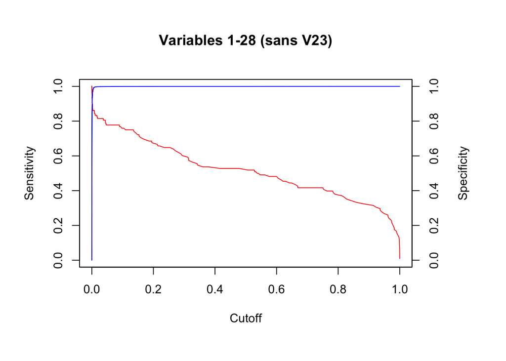

```r
graph.x = cutoffs
graph.y1 = truepositive/Fraudrows
graph.y2 = truenegative/Nonfraudrows

par(mar=c(6,5,5,6)+0.5)
plot(graph.x,graph.y1,type="l",col="red",yaxt="n",xlab="",ylab="", main="Variables 1-28 (sans V23)")
axis(2)
par(new=TRUE)
plot(graph.x, graph.y2,type="l",col="blue",xaxt="n",yaxt="n",xlab="",ylab="")
axis(4)
mtext("Specificity",side=4,line=3)
mtext("Sensitivity",side=2,line=3)
mtext("Cutoff",side=1,line=3)
```

Creating data for the table

```r
Model[1,1] = "Amount, V1 - V28"
Model[1,2] = truepositive[max.sensitivity.specificity.Index]
Model[1,3] = falsepositive[max.sensitivity.specificity.Index]
Model[1,4] = cutoffs[max.sensitivity.specificity.Index]
Model[1,5] = (truepositive[max.sensitivity.specificity.Index] + truenegative[max.sensitivity.specificity.Index])/test.data.calc
Model[1,6] = truepositive[max.truepositive.index]
Model[1,7] = falsepositive[max.truepositive.index]
Model[1,8] = cutoffs[max.truepositive.index]
Model[1,9] = (truepositive[max.truepositive.index] + truenegative[max.truepositive.index])/test.data.calc
Model[1,10] = truepositive[mid.cutoff.index]
Model[1,11] = falsepositive[mid.cutoff.index]
Model[1,12] = cutoffs[mid.cutoff.index]
Model[1,13] = (truepositive[mid.cutoff.index] + truenegative[mid.cutoff.index])/test.data.calc
Model[1,14] = Accuracy
Model[1,15] = auc
Model[1,16] = prc$auc.integral
```

```r
glm.model
```

```
##
## Call:  glm(formula = Class ~ . - V23, family = binomial(link = "logit"),
##     data = traindata.iteration)
##
## Coefficients:
## (Intercept)       Amount           V1           V2           V3
##   -8.582542     0.001513     0.067595     0.101937     0.114602
##          V4           V5           V6           V7           V8
##    0.654379     0.030648    -0.199859    -0.151218    -0.142110
##          V9          V10          V11          V12          V13
##   -0.215170    -0.774731    -0.033116     0.038150    -0.267182
##         V14          V15          V16          V17          V18
##   -0.532823    -0.037202    -0.123304     0.045176     0.110200
##         V19          V20          V21          V22          V24
##    0.024573    -0.528937     0.316533     0.510773    -0.061725
##         V25          V26          V27          V28
##   -0.006089     0.228204    -0.858569    -0.319903
##
## Degrees of Freedom: 199363 Total (i.e. Null);  199335 Residual
## Null Deviance:       5569
## Residual Deviance: 1747  AIC: 1805
```